# Chapter 3: Environmental and Social Determinants of Cognitive Health in Puente Piedra, Peru

## 2.18 View results

```
##                 outcome estimate conf.low conf.high p.value
## 1 DC binary (clustered)    1.072    0.930     1.237   0.336
## 2     RUDAS (clustered)    0.069   -0.403     0.542   0.775
## 3       ACE (clustered)   -0.924   -1.565    -0.283   0.005
```

## 2.19 Figure

```
## # A tibble: 4 × 5
##   buffer_zone pct_dc mean_rudas mean_ace     n
##   <fct>        <dbl>      <dbl>    <dbl> <int>
## 1 Within 100m   10.7       23.1     81.7   112
## 2 100–500m      12.9       24.2     79.6   272
## 3 500m–1km      17.0       23.9     77.8   358
## 4 Beyond 1km    15.7       23.7     78.4   324
```

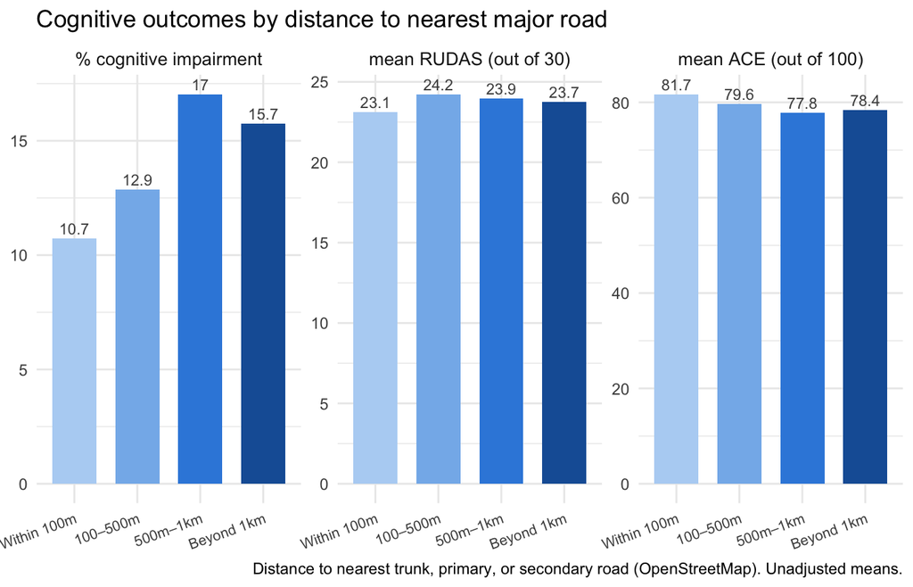

## 2.20 Add in SES level

```
##
## NSE E NSE D NSE C NSE B NSE A  <NA>
##    60    93   339   487    78     9
```

```
## # A tibble: 6 × 5
##   ses_level pct_dc mean_rudas mean_ace     n
##   <fct>      <dbl>      <dbl>    <dbl> <int>
## 1 NSE E      33.3        24.5     73.0    60
## 2 NSE D      21.5        23.6     73.1    93
## 3 NSE C      18.9        23.7     76.8   339
## 4 NSE B       9.24       23.9     81.5   487
## 5 NSE A       8.97       24.5     83.1    78
## 6 <NA>       33.3        24       72       9
```

```
## # A tibble: 6 × 4
##   ses_level mean_pm25 mean_dist_road     n
##   <fct>         <dbl>          <dbl> <int>
## 1 NSE E          33.4          1240.    60
## 2 NSE D          33.2           808.    93
## 3 NSE C          33.4          1082.   339
## 4 NSE B          33.6           975.   487
## 5 NSE A          33.5           826.    78
## 6 <NA>           34.2          1324.     9
```

# 3 Re-run models

```
##                      outcome       model estimate conf.low conf.high p.value
## 1      DC binary (clustered) without SES    1.072    0.930     1.237   0.336
## 2 DC binary (SES, clustered)    with SES    1.041    0.902     1.201   0.583
## 3          RUDAS (clustered) without SES    0.069   -0.403     0.542   0.775
## 4     RUDAS (SES, clustered)    with SES    0.195   -0.288     0.678   0.430
## 5            ACE (clustered) without SES   -0.924   -1.565    -0.283   0.005
## 6       ACE (SES, clustered)    with SES   -0.785   -1.403    -0.166   0.013
```

For ACE in younger adults, the road proximity effect attenuates modestly after SES adjustment (β −0.92 without SES vs β −0.78 with SES) but remains statistically significant (p=0.013). SES accounts for roughly 15% of the original effect estimate — consistent with the descriptive finding that lower-SES participants tend to live slightly farther from major roads — but does not explain it away. The association remains statistically significant after SES adjustment (β −0.785, 95% CI −1.40– −0.17, p=0.013). The association between greater distance from major roads and lower ACE scores in 30–59 year olds is robust to socioeconomic adjustment.

This pattern suggests the road proximity effect in younger adults is not simply a proxy for SES, though both urbanization and socioeconomic resources likely operate through related pathways — access to healthcare, education, and economic opportunity — in this peri-urban Lima context.

## 3.1 The *storyline* for the chapter:

*Implication — future studies need personal, granular exposure monitors + SES adjustment to disentangle pollution from access; indoor air monitoring*

## 3.2 Summary table of exposure variables

```
## Simple feature collection with 1 feature and 18 fields
## Geometry type: MULTIPOINT
## Dimension:     XYZ
## Bounding box:  xmin: 268493.9 ymin: 8678543 xmax: 276035.8 ymax: 8693834
## z_range:       zmin: 0 zmax: 0
## Projected CRS: WGS 84 / UTM zone 18S
##   Mean_ACE   SD_ACE n_ACE Mean_RUDAS SD_RUDAS n_RUDAS Mean_Humidity SD_Humidity
## 1 78.81952 11.34903   753   23.89024 3.292122     328      55.60066   0.6890993
##   n_Humidity Mean_Temp   SD_Temp n_Temp Mean_PM25  SD_PM25 n_PM25 Mean_PM10
## 1       1066  77.44994 0.5881556   1066  33.49201 1.709741   1066  39.87847
##    SD_PM10 n_PM10                       geometry
## 1 2.028753   1066 MULTIPOINT Z ((268493.9 869...
```

## 3.3 Summary tables by sensor

## 3.4 CURRENTLY NOT INCLUDING THIS IN THE MANUSCRIPT !!!!!

## 3.5 Change exposure gradient

# clean exposure variable

# primary model (continuous exposure)

```
## # A tibble: 4 × 7
##   term          estimate std.error statistic   p.value conf.low conf.high
##   <chr>            <dbl>     <dbl>     <dbl>     <dbl>    <dbl>     <dbl>
## 1 (Intercept)      0.261   0.592      -2.27  0.0232      0.0804     0.820
## 2 log_dist_road    1.07    0.0721      0.971 0.332       0.934      1.24
## 3 age_n            0.988   0.00650    -1.90  0.0575      0.975      1.00
## 4 sexMasculino     0.351   0.243      -4.31  0.0000160   0.213      0.554
```

# sensitivity model (buffer categories)

```
## # A tibble: 5 × 7
##   term                  estimate std.error statistic  p.value conf.low conf.high
##   <chr>                    <dbl>     <dbl>     <dbl>    <dbl>    <dbl>     <dbl>
## 1 (Intercept)              0.441   0.323      -2.54   1.12e-2    0.233     0.830
## 2 road_exposure≤100m       0.640   0.326      -1.37   1.71e-1    0.322     1.17
## 3 road_exposure100–500m    0.816   0.212      -0.961  3.37e-1    0.532     1.22
## 4 age_n                    0.988   0.00649    -1.86   6.35e-2    0.975     1.00
## 5 sexMasculino             0.350   0.243      -4.32   1.54e-5    0.213     0.553
```

# cleaned combined output

```
## # A tibble: 9 × 6
##   model                     term             estimate conf.low conf.high p.value
##   <chr>                     <chr>               <dbl>    <dbl>     <dbl>   <dbl>
## 1 Continuous (log distance) (Intercept)         0.261   0.0804     0.820 2.32e-2
## 2 Continuous (log distance) log_dist_road       1.07    0.934      1.24  3.32e-1
## 3 Continuous (log distance) age_n               0.988   0.975      1.00  5.75e-2
## 4 Continuous (log distance) sexMasculino        0.351   0.213      0.554 1.60e-5
## 5 Buffer zones              (Intercept)         0.441   0.233      0.830 1.12e-2
## 6 Buffer zones              road_exposure≤1…    0.640   0.322      1.17  1.71e-1
## 7 Buffer zones              road_exposure10…    0.816   0.532      1.22  3.37e-1
## 8 Buffer zones              age_n               0.988   0.975      1.00  6.35e-2
## 9 Buffer zones              sexMasculino        0.350   0.213      0.553 1.54e-5
```

```
## # A tibble: 9 × 6
##   model        term                  estimate conf.low conf.high   p.value
##   <chr>        <chr>                    <dbl>    <dbl>     <dbl>     <dbl>
## 1 Continuous   (Intercept)              0.261    0.08      0.82  0.0232
## 2 Continuous   log_dist_road            1.07     0.934     1.24  0.332
## 3 Continuous   age_n                    0.988    0.975     1     0.0575
## 4 Continuous   sexMasculino             0.351    0.213     0.554 0.0000160
## 5 Buffer zones (Intercept)              0.441    0.233     0.83  0.0112
## 6 Buffer zones road_exposure≤100m       0.64     0.322     1.17  0.171
## 7 Buffer zones road_exposure100–500m    0.816    0.532     1.23  0.337
## 8 Buffer zones age_n                    0.988    0.975     1.00  0.0635
## 9 Buffer zones sexMasculino             0.35     0.213     0.553 0.0000154
```

# predicted probability plot

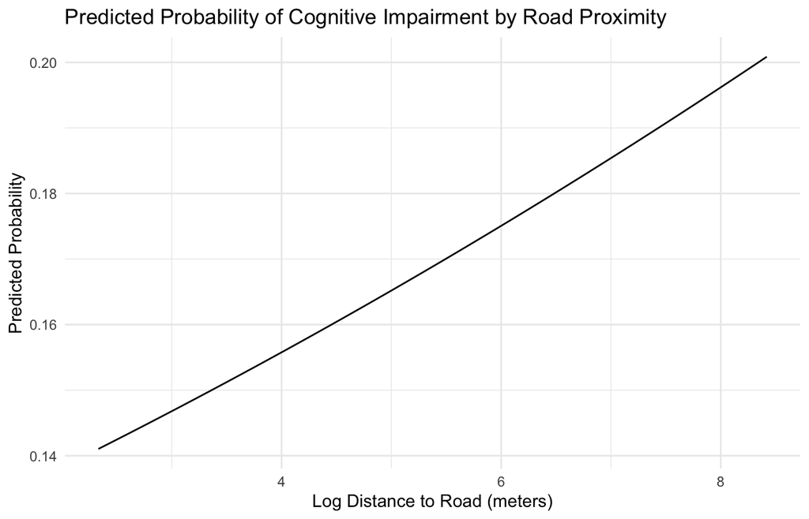

# simple buffer comparison

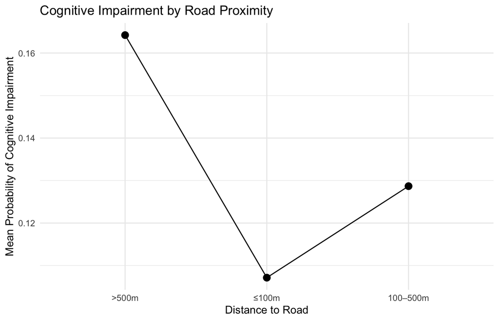

## 3.6 Re-run models for each road type

```
##                 outcome estimate conf.low conf.high p.value
## 1     DC binary — trunk    1.045    0.861     1.268   0.656
## 2         RUDAS — trunk   -0.031   -0.663     0.600   0.922
## 3           ACE — trunk   -0.867   -1.722    -0.011   0.048
## 4   DC binary — primary    0.948    0.704     1.277   0.727
## 5       RUDAS — primary    0.247   -1.425     1.919   0.773
## 6         ACE — primary    1.146   -0.138     2.430   0.081
## 7 DC binary — secondary    1.032    0.895     1.190   0.663
## 8     RUDAS — secondary    0.255   -0.230     0.740   0.306
## 9       ACE — secondary   -0.828   -1.425    -0.231   0.007
```

In road-type stratified sensitivity analyses, the inverse association between road proximity and ACE scores in younger adults was consistent for trunk (β −0.87, p=0.048) and secondary roads (β −0.83, p=0.007), suggesting the pooled result is not attributable to any single road classification. The primary road estimate was in the opposite direction but did not reach statistical significance (β +1.15, p=0.081), possibly reflecting the distinct spatial distribution of primary roads in this peri-urban context.

```
## # A tibble: 6 × 6
##   nearest_sensor_name          n mean_dist_any mean_dist_trunk mean_dist_primary
##   <chr>                    <int>         <dbl>           <dbl>             <dbl>
## 1 GEOHealth_PuenteP_Estad…   361           408             851              3705
## 2 GeoHealth_Comas_2055PAb…    54           796             807              1792
## 3 GEOHealth_MiPeru_Chavin…   501           888            1059              1887
## 4 GEOHealth_Ventanilla_NS…    19          1112            1999              3102
## 5 GEOHealth_Carab_VictorR…     4          1161            1161              1602
## 6 GEOHealth_SanMa_IE005      127          3200            3681              3291
## # ℹ 1 more variable: mean_dist_secondary <dbl>
```

## 3.7 More descriptive statisitcs [yes, including in manuscript]

For continuous covariates by sensor i.e. age, BMI

```
## # A tibble: 6 × 6
##   nearest_sensor_name              n age_mean age_sd bmi_mean bmi_sd
##   <chr>                        <int>    <dbl>  <dbl>    <dbl>  <dbl>
## 1 GEOHealth_Carab_VictorRaulHT     4     55     14.9     26.3   2.22
## 2 GEOHealth_MiPeru_Chavinillo    501     50.6   14.8     29.0   5.08
## 3 GEOHealth_PuenteP_Estadio_1    361     51.5   14.0     28.7   4.92
## 4 GEOHealth_SanMa_IE005          127     49.8   14.4     28.7   4.47
## 5 GEOHealth_Ventanilla_NSBelen    19     46.5   13.8     30.8   6.06
## 6 GeoHealth_Comas_2055PAbril      54     52.2   14.8     28.1   4.78
```

# Categorical covariates by sensor (i.e., sex, education, insurance)

```
## # A tibble: 12 × 4
## # Groups:   nearest_sensor_name [6]
##    nearest_sensor_name          sex           n percent
##    <chr>                        <chr>     <int>   <dbl>
##  1 GEOHealth_Carab_VictorRaulHT Femenino      3    75
##  2 GEOHealth_Carab_VictorRaulHT Masculino     1    25
##  3 GEOHealth_MiPeru_Chavinillo  Femenino    351    70.1
##  4 GEOHealth_MiPeru_Chavinillo  Masculino   150    29.9
##  5 GEOHealth_PuenteP_Estadio_1  Femenino    241    66.8
##  6 GEOHealth_PuenteP_Estadio_1  Masculino   120    33.2
##  7 GEOHealth_SanMa_IE005        Femenino     94    74.0
##  8 GEOHealth_SanMa_IE005        Masculino    33    26.0
##  9 GEOHealth_Ventanilla_NSBelen Femenino     16    84.2
## 10 GEOHealth_Ventanilla_NSBelen Masculino     3    15.8
## 11 GeoHealth_Comas_2055PAbril   Femenino     40    74.1
## 12 GeoHealth_Comas_2055PAbril   Masculino    14    25.9
```

```
## # A tibble: 16 × 4
## # Groups:   nearest_sensor_name [6]
##    nearest_sensor_name          education_cat           n percent
##    <chr>                        <fct>               <int>   <dbl>
##  1 GEOHealth_Carab_VictorRaulHT primary                 1   25
##  2 GEOHealth_Carab_VictorRaulHT secondary_or_higher     3   75
##  3 GEOHealth_MiPeru_Chavinillo  none                   26    5.19
##  4 GEOHealth_MiPeru_Chavinillo  primary               148   29.5
##  5 GEOHealth_MiPeru_Chavinillo  secondary_or_higher   327   65.3
##  6 GEOHealth_PuenteP_Estadio_1  none                   13    3.60
##  7 GEOHealth_PuenteP_Estadio_1  primary                98   27.1
##  8 GEOHealth_PuenteP_Estadio_1  secondary_or_higher   250   69.3
##  9 GEOHealth_SanMa_IE005        none                   10    7.87
## 10 GEOHealth_SanMa_IE005        primary                25   19.7
## 11 GEOHealth_SanMa_IE005        secondary_or_higher    92   72.4
## 12 GEOHealth_Ventanilla_NSBelen primary                 7   36.8
## 13 GEOHealth_Ventanilla_NSBelen secondary_or_higher    12   63.2
## 14 GeoHealth_Comas_2055PAbril   none                    5    9.26
## 15 GeoHealth_Comas_2055PAbril   primary                18   33.3
## 16 GeoHealth_Comas_2055PAbril   secondary_or_higher    31   57.4
```

# Checking multiple variables >> stacked descriptive dataset

```
## # A tibble: 152 × 5
## # Groups:   nearest_sensor_name, variable [54]
##    nearest_sensor_name          variable       value                   n percent
##    <chr>                        <chr>          <chr>               <int>   <dbl>
##  1 GEOHealth_Carab_VictorRaulHT chronic_dis    No                      2      50
##  2 GEOHealth_Carab_VictorRaulHT chronic_dis    Sí                      2      50
##  3 GEOHealth_Carab_VictorRaulHT civil_stat_cat partnered               3      75
##  4 GEOHealth_Carab_VictorRaulHT civil_stat_cat separated_widowed       1      25
##  5 GEOHealth_Carab_VictorRaulHT education_cat  primary                 1      25
##  6 GEOHealth_Carab_VictorRaulHT education_cat  secondary_or_higher     3      75
##  7 GEOHealth_Carab_VictorRaulHT health_ins_cat Essalud                 3      75
##  8 GEOHealth_Carab_VictorRaulHT health_ins_cat SIS                     1      25
##  9 GEOHealth_Carab_VictorRaulHT htn_cat        none                    4     100
## 10 GEOHealth_Carab_VictorRaulHT native_lang    Castellano              4     100
## # ℹ 142 more rows
```

# Cleaner formatting

| **Characteristic** | **GEOHealth_Carab_VictorRaulHT** N = 4<sup>1</sup> | **GeoHealth_Comas_2055PAbril** N = 54<sup>1</sup> | **GEOHealth_MiPeru_Chavinillo** N = 501<sup>1</sup> | **GEOHealth_PuenteP_Estadio_1** N = 361<sup>1</sup> | **GEOHealth_SanMa_IE005** N = 127<sup>1</sup> | **GEOHealth_Ventanilla_NSBelen** N = 19<sup>1</sup> |
| --- | --- | --- | --- | --- | --- | --- |
| age | 54 (44, 66) | 53 (40, 64) | 48 (38, 62) | 50 (40, 62) | 48 (36, 60) | 45 (34, 63) |
| sex |  |  |  |  |  |  |
| Femenino | 3 (75%) | 40 (74%) | 351 (70%) | 241 (67%) | 94 (74%) | 16 (84%) |
| Masculino | 1 (25%) | 14 (26%) | 150 (30%) | 120 (33%) | 33 (26%) | 3 (16%) |
| education_cat |  |  |  |  |  |  |
| none | 0 (0%) | 5 (9.3%) | 26 (5.2%) | 13 (3.6%) | 10 (7.9%) | 0 (0%) |
| primary | 1 (25%) | 18 (33%) | 148 (30%) | 98 (27%) | 25 (20%) | 7 (37%) |
| secondary_or_higher | 3 (75%) | 31 (57%) | 327 (65%) | 250 (69%) | 92 (72%) | 12 (63%) |
| civil_stat_cat |  |  |  |  |  |  |
| partnered | 3 (75%) | 30 (56%) | 320 (64%) | 225 (63%) | 88 (69%) | 9 (47%) |
| single | 0 (0%) | 15 (28%) | 103 (21%) | 74 (21%) | 19 (15%) | 6 (32%) |
| separated_widowed | 1 (25%) | 9 (17%) | 78 (16%) | 61 (17%) | 20 (16%) | 4 (21%) |
| Unknown | 0 | 0 | 0 | 1 | 0 | 0 |
| bmi | 26.2 (24.9, 27.7) | 27.6 (24.5, 29.4) | 28.6 (25.5, 32.0) | 28.0 (25.5, 31.0) | 28.2 (25.1, 31.2) | 29.4 (28.1, 31.2) |
| Unknown | 0 | 0 | 2 | 3 | 0 | 0 |
| htn_cat |  |  |  |  |  |  |
| none | 4 (100%) | 44 (81%) | 367 (73%) | 261 (72%) | 100 (79%) | 15 (79%) |
| hypertension | 0 (0%) | 10 (19%) | 133 (27%) | 100 (28%) | 27 (21%) | 4 (21%) |
| Unknown | 0 | 0 | 1 | 0 | 0 | 0 |
| native_lang |  |  |  |  |  |  |
| Castellano | 4 (100%) | 41 (76%) | 407 (81%) | 288 (80%) | 95 (75%) | 13 (68%) |
| Quechua o aimara | 0 (0%) | 13 (24%) | 94 (19%) | 73 (20%) | 32 (25%) | 6 (32%) |
| health_ins_cat |  |  |  |  |  |  |
| SIS | 1 (25%) | 37 (69%) | 293 (58%) | 188 (52%) | 79 (62%) | 11 (58%) |
| Essalud | 3 (75%) | 8 (15%) | 102 (20%) | 89 (25%) | 18 (14%) | 4 (21%) |
| uninsured | 0 (0%) | 6 (11%) | 68 (14%) | 55 (15%) | 23 (18%) | 2 (11%) |
| other | 0 (0%) | 3 (5.6%) | 38 (7.6%) | 29 (8.0%) | 7 (5.5%) | 2 (11%) |
| occupation_cat |  |  |  |  |  |  |
| employed | 1 (25%) | 22 (41%) | 235 (47%) | 150 (42%) | 50 (39%) | 6 (32%) |
| homemaker | 2 (50%) | 15 (28%) | 156 (31%) | 121 (34%) | 54 (43%) | 10 (53%) |
| not_employed | 1 (25%) | 17 (31%) | 109 (22%) | 90 (25%) | 23 (18%) | 3 (16%) |
| Unknown | 0 | 0 | 1 | 0 | 0 | 0 |
| chronic_dis |  |  |  |  |  |  |
| No | 2 (50%) | 39 (72%) | 315 (63%) | 219 (61%) | 80 (63%) | 12 (63%) |
| Sí | 2 (50%) | 15 (28%) | 186 (37%) | 142 (39%) | 47 (37%) | 7 (37%) |
| ses_level |  |  |  |  |  |  |
| NSE E | 0 (0%) | 4 (7.5%) | 32 (6.4%) | 14 (3.9%) | 7 (5.6%) | 3 (16%) |
| NSE D | 0 (0%) | 1 (1.9%) | 53 (11%) | 30 (8.4%) | 9 (7.2%) | 0 (0%) |
| NSE C | 1 (25%) | 14 (26%) | 161 (32%) | 112 (31%) | 43 (34%) | 8 (42%) |
| NSE B | 3 (75%) | 31 (58%) | 218 (44%) | 169 (47%) | 59 (47%) | 7 (37%) |
| NSE A | 0 (0%) | 3 (5.7%) | 36 (7.2%) | 31 (8.7%) | 7 (5.6%) | 1 (5.3%) |
| Unknown | 0 | 1 | 1 | 5 | 2 | 0 |

<sup>1</sup> Median (Q1, Q3); n (%)

# Quick diagnostic visualization Super important: my exposure assignment is sensor-based, so if covariates cluster by sensor, it suggests potential spatial confounding (e.g., SES or age differences by neighborhood).

However, this quick visual does not suggest spatial confounding by age. Medians are fairly similar (~45-55 years). Interquartile ranges overlap a lot. Some sensors do have longer upper tails. - GEOHealth_Carab_VictorRaulHT → slightly older median (~52–53) - GEOHealth_Ventanilla_NSBelen → slightly younger (~45–47)

- A few sensors (e.g., PuenteP_Estadio_1, MiPeru_Chavinillo) extend to ~90+. a few older participants near those sensors, but since the median and IQR are similar, this is unlikely to drive systematic confounding.

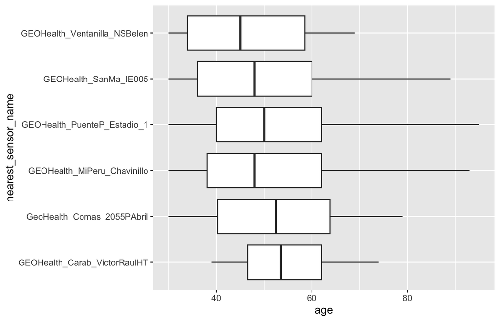

```
## # A tibble: 29 × 4
## # Groups:   nearest_sensor_name [6]
##    nearest_sensor_name          ses_quint       n      p
##    <chr>                        <chr>       <int>  <dbl>
##  1 GEOHealth_Carab_VictorRaulHT 3er quintil     3 0.75
##  2 GEOHealth_Carab_VictorRaulHT 4to quintil     1 0.25
##  3 GEOHealth_MiPeru_Chavinillo  1er quintil   111 0.222
##  4 GEOHealth_MiPeru_Chavinillo  2do quintil   111 0.222
##  5 GEOHealth_MiPeru_Chavinillo  3er quintil    71 0.142
##  6 GEOHealth_MiPeru_Chavinillo  4to quintil   129 0.257
##  7 GEOHealth_MiPeru_Chavinillo  5to quintil    55 0.110
##  8 GEOHealth_MiPeru_Chavinillo  <NA>           24 0.0479
##  9 GEOHealth_PuenteP_Estadio_1  1er quintil    63 0.175
## 10 GEOHealth_PuenteP_Estadio_1  2do quintil    66 0.183
## # ℹ 19 more rows
```

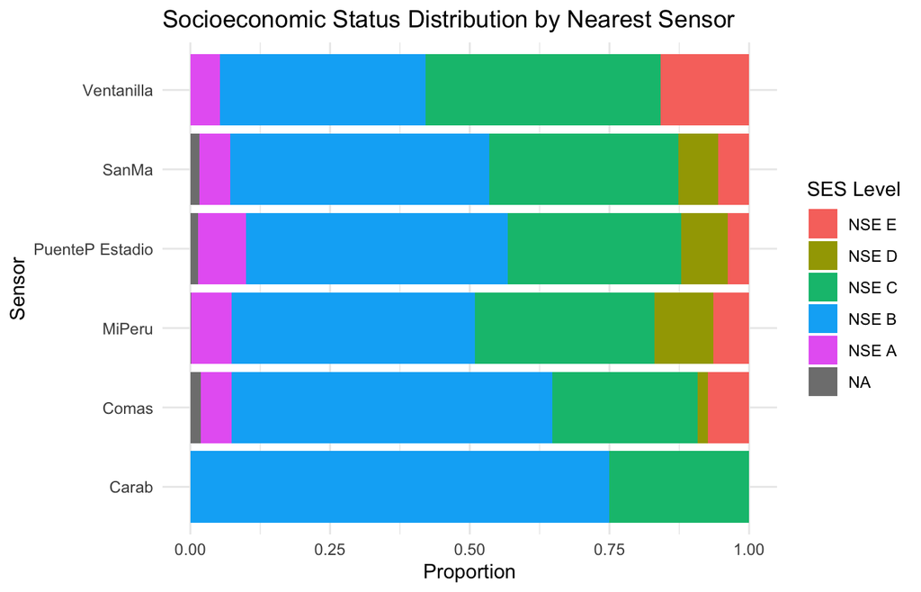

```
## # A tibble: 6 × 7
##   nearest_sensor_name `NSE C` `NSE B` `NSE E` `NSE D` `NSE A`     `NA`
##   <chr>                 <dbl>   <dbl>   <dbl>   <dbl>   <dbl>    <dbl>
## 1 Carab                 0.25    0.75  NA      NA      NA      NA
## 2 MiPeru                0.321   0.435  0.0639  0.106   0.0719  0.00200
## 3 PuenteP Estadio       0.310   0.468  0.0388  0.0831  0.0859  0.0139
## 4 SanMa                 0.339   0.465  0.0551  0.0709  0.0551  0.0157
## 5 Ventanilla            0.421   0.368  0.158  NA       0.0526 NA
## 6 Comas                 0.259   0.574  0.0741  0.0185  0.0556  0.0185
```

## 3.8 Chi-Square / Kruskal-Wallis Tests by Sector

Covariate balance across sensor zones

| variable | test | chi_sq | df | p_value | sig |
| --- | --- | --- | --- | --- | --- |
| sex | Chi-square | 5.07 | NA | 0.4228 |  |
| education_cat | Chi-square | 13.20 | NA | 0.2019 |  |
| civil_stat_cat | Chi-square | 8.15 | NA | 0.6167 |  |
| native_lang | Chi-square | 5.56 | NA | 0.3578 |  |
| health_ins_cat | Chi-square | 20.46 | NA | 0.1639 |  |
| occupation_cat | Chi-square | 14.38 | NA | 0.1354 |  |
| chronic_dis | Chi-square | 3.01 | NA | 0.7021 |  |
| glucose_cat | Chi-square | 15.85 | NA | 0.1004 |  |
| htn_cat | Chi-square | 5.33 | NA | 0.3758 |  |
| ses_level | Chi-square | 20.69 | NA | 0.4063 |  |
| age | Kruskal-Wallis | 4.67 | 5 | 0.4579 |  |
| bmi | Kruskal-Wallis | 6.95 | 5 | 0.2247 |  |
| rudas | Kruskal-Wallis | 3.43 | 4 | 0.4881 |  |
| ace_score | Kruskal-Wallis | 3.44 | 5 | 0.6328 |  |
| exposure_pm25 | Kruskal-Wallis | 1065.00 | 5 | 0.0000 | *** |
| exposure_pm10 | Kruskal-Wallis | 1065.00 | 5 | 0.0000 | *** |
| exposure_temp | Kruskal-Wallis | 1065.00 | 5 | 0.0000 | *** |
| exposure_humidity | Kruskal-Wallis | 1065.00 | 5 | 0.0000 | *** |

No covariate differs significantly across sensor zones (all p > 0.05). This means sensor-zone exposure assignment is not systematically confounded by who lives where — age, SES, education, civil status, etc. are distributed comparably across zones, strengthening our argument.

the NA in the df column for chi-square is expected; it happens because we used simulate.p.value = TRUE, which runs a Monte Carlo permutation test instead of the standard asymptotic chi-square. The simulated version doesn’t return degrees of freedom. Potential footnote: p-values estimated via Monte Carlo simulation (B = 2000) due to small expected cell counts in some zones.

Add to manuscript: To assess potential spatial confounding, we tested whether key sociodemographic and health covariates differed across sensor zones using chi-square tests (categorical variables) and Kruskal-Wallis tests (continuous variables). No significant differences were observed (all p > 0.05; Supplementary Table X), suggesting that exposure assignment was not systematically associated with participant characteristics.

New figure with error bars for: Distribution of Dementia Status by SES Level

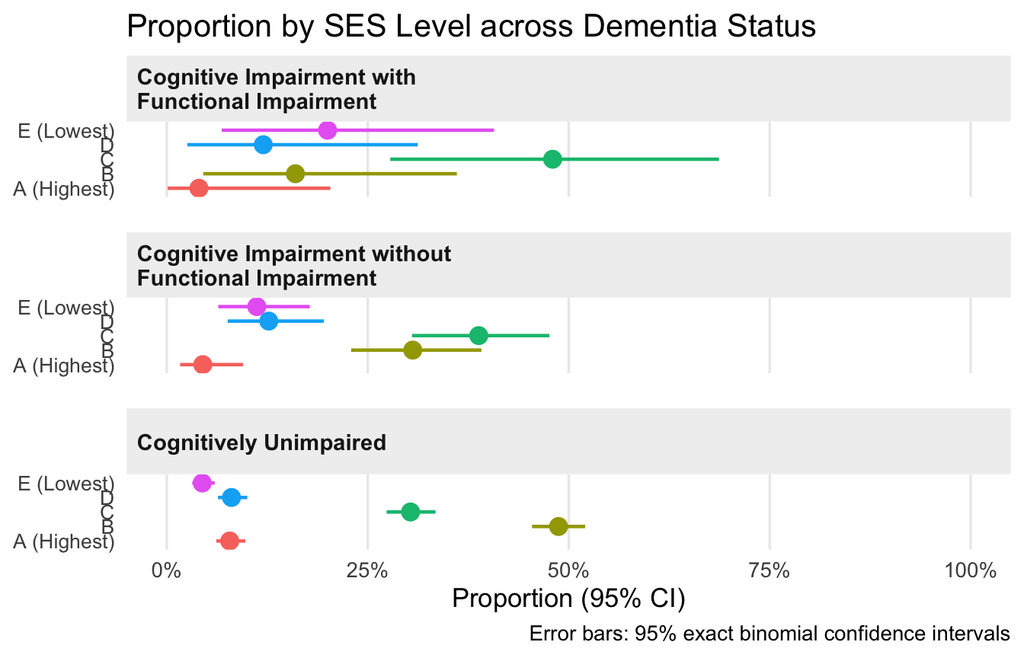

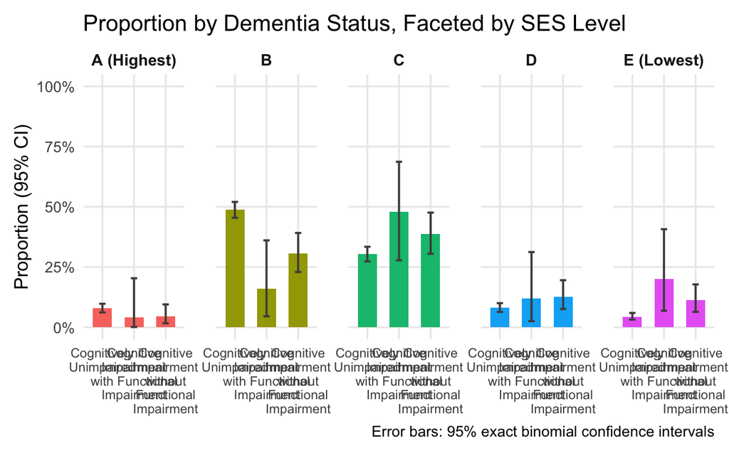

## 3.9 Map figure

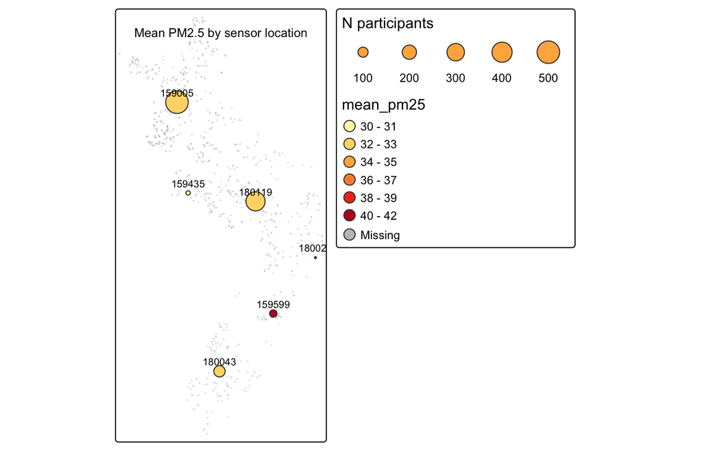

## 3.10 Does SES predict road proximity?

```
## # A tibble: 6 × 4
##   ses_level mean_dist_road median_dist_road     n
##   <fct>              <dbl>            <dbl> <int>
## 1 NSE E              1240.             853.    60
## 2 NSE D               808.             554.    93
## 3 NSE C              1082.             697.   339
## 4 NSE B               975.             688.   487
## 5 NSE A               826.             548.    78
## 6 <NA>               1324.             870.     9
```

## 3.11 Is the SES-road relationship statistically significant?

```
##
## Call:
## lm(formula = dist_to_road_m ~ ses_level, data = st_drop_geometry(spatial_data_proj))
##
## Residuals:
##     Min      1Q  Median      3Q     Max
## -1226.9  -652.7  -314.0   198.5  3520.9
##
## Coefficients:
##                Estimate Std. Error t value Pr(>|t|)
## (Intercept)      1239.8      128.6   9.640   <2e-16 ***
## ses_levelNSE D   -431.7      165.0  -2.617   0.0090 **
## ses_levelNSE C   -157.5      139.5  -1.129   0.2593
## ses_levelNSE B   -265.2      136.3  -1.946   0.0520 .
## ses_levelNSE A   -414.1      171.1  -2.421   0.0157 *
## ---
## Signif. codes:  0 '***' 0.001 '**' 0.01 '*' 0.05 '.' 0.1 ' ' 1
##
## Residual standard error: 996.2 on 1052 degrees of freedom
##   (9 observations deleted due to missingness)
## Multiple R-squared:  0.01123,    Adjusted R-squared:  0.007467
## F-statistic: 2.986 on 4 and 1052 DF,  p-value: 0.0182
```

## 3.12 Does SES vary within road distance buffers?

```
## # A tibble: 4 × 7
##   buffer_zone `NSE E` `NSE D` `NSE C` `NSE B` `NSE A`  `NA`
##   <chr>         <int>   <int>   <int>   <int>   <int> <int>
## 1 100–500m          7      25      88     126      23     3
## 2 500m–1km         22      31     115     168      21     1
## 3 Beyond 1km       27      20     111     140      22     4
## 4 Within 100m       4      17      25      53      12     1
```

## 3.13 Colinearity with temp, humidity, pm 2.5, pm 10

```
##                   exposure_pm25 exposure_pm10 exposure_temp exposure_humidity
## exposure_pm25              1.00          0.82         -0.49             -0.54
## exposure_pm10              0.82          1.00         -0.45             -0.81
## exposure_temp             -0.49         -0.45          1.00             -0.01
## exposure_humidity         -0.54         -0.81         -0.01              1.00
```

```
##     exposure_pm25_z     exposure_pm10_z     exposure_temp_z exposure_humidity_z
##            3.186644           10.176890            2.291924            5.822657
##               age_n                 sex
##            1.016892            1.001693
```

## 3.14 Correlations?

```
##                     dist_to_road_m ses_numeric age_n sex_numeric dc_binary
## dist_to_road_m                1.00       -0.10 -0.19        0.04     -0.03
## ses_numeric                  -0.10        1.00  0.12       -0.18     -0.21
## age_n                        -0.19        0.12  1.00       -0.10      0.16
## sex_numeric                   0.04       -0.18 -0.10        1.00      0.16
## dc_binary                    -0.03       -0.21  0.16        0.16      1.00
## rudas_n                      -0.03        0.05 -0.07        0.00      0.09
## ace_n                         0.10        0.38 -0.23       -0.11     -0.70
## education_numeric             0.01        0.23 -0.21       -0.23     -0.43
## health_ins_numeric           -0.07        0.00  0.07       -0.08     -0.06
## occupation_numeric           -0.01       -0.14  0.15        0.28      0.02
## chronic_dis_numeric           0.05        0.10  0.27        0.08     -0.02
## bmi                          -0.04        0.02  0.23        0.03      0.03
##                     rudas_n ace_n education_numeric health_ins_numeric
## dist_to_road_m        -0.03  0.10              0.01              -0.07
## ses_numeric            0.05  0.38              0.23               0.00
## age_n                 -0.07 -0.23             -0.21               0.07
## sex_numeric            0.00 -0.11             -0.23              -0.08
## dc_binary              0.09 -0.70             -0.43              -0.06
## rudas_n                1.00 -0.06              0.02               0.08
## ace_n                 -0.06  1.00              0.48               0.12
## education_numeric      0.02  0.48              1.00              -0.01
## health_ins_numeric     0.08  0.12             -0.01               1.00
## occupation_numeric    -0.07 -0.07             -0.14              -0.02
## chronic_dis_numeric    0.04  0.06             -0.10              -0.04
## bmi                    0.10 -0.07             -0.09               0.02
##                     occupation_numeric chronic_dis_numeric   bmi
## dist_to_road_m                   -0.01                0.05 -0.04
## ses_numeric                      -0.14                0.10  0.02
## age_n                             0.15                0.27  0.23
## sex_numeric                       0.28                0.08  0.03
## dc_binary                         0.02               -0.02  0.03
## rudas_n                          -0.07                0.04  0.10
## ace_n                            -0.07                0.06 -0.07
## education_numeric                -0.14               -0.10 -0.09
## health_ins_numeric               -0.02               -0.04  0.02
## occupation_numeric                1.00                0.07  0.08
## chronic_dis_numeric               0.07                1.00  0.13
## bmi                               0.08                0.13  1.00
```

## 3.15 road proximity table

## 3.16 Interaction Term

```
##
## t test of coefficients:
##
##                              Estimate Std. Error t value Pr(>|t|)
## (Intercept)                    69.996     10.031   6.978   <2e-16 ***
## log_dist_road                   2.226      1.397   1.593    0.112
## ses_levelNSE D                 26.457     13.094   2.021    0.044 *
## ses_levelNSE C                 29.726     10.623   2.798    0.005 **
## ses_levelNSE B                 28.717     10.110   2.840    0.005 **
## ses_levelNSE A                 28.603     10.539   2.714    0.007 **
## age_n                          -0.326      0.044  -7.367   <2e-16 ***
## sexMasculino                    3.240      0.838   3.866   <2e-16 ***
## log_dist_road:ses_levelNSE D   -3.791      1.972  -1.922    0.055 .
## log_dist_road:ses_levelNSE C   -3.710      1.525  -2.433    0.015 *
## log_dist_road:ses_levelNSE B   -2.841      1.445  -1.966    0.050 *
## log_dist_road:ses_levelNSE A   -2.569      1.524  -1.686    0.092 .
## ---
## Signif. codes:  0 '***' 0.001 '**' 0.01 '*' 0.05 '.' 0.1 ' ' 1
```

## 3.17 figure for interaction

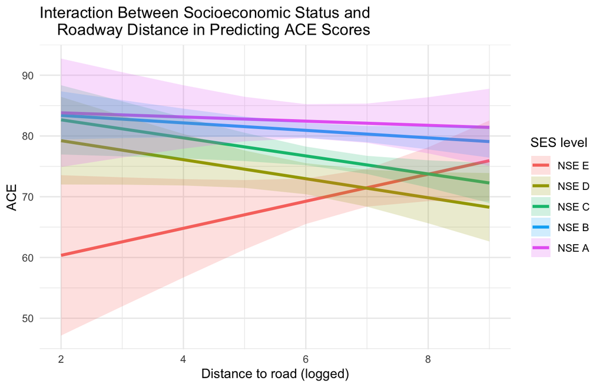

## 3.18 Re-structuring results to be organized

- Basic statistics
- Unadjusted models
- Adjusted models

Check missingness:

```
## # A tibble: 13 × 2
##    variable       pct_missing
##    <chr>                <dbl>
##  1 rudas_n               69.2
##  2 ace_n                 29.4
##  3 glucose_cat            2.6
##  4 ses_level              0.8
##  5 bmi                    0.5
##  6 civil_stat_cat         0.1
##  7 occupation_cat         0.1
##  8 htn_cat                0.1
##  9 dc_binary              0
## 10 age_n                  0
## 11 sex                    0
## 12 education_cat          0
## 13 chronic_dis            0
```

The missingness is mostly expected and minor:

- rudas_n (69.2%) and ace_n (29.4%) — not real missingness, just age-group specific instruments. Expected.
- glucose_cat (2.6%) — fine to include
- Everything else <1% — no concerns

```
##      outcome    exposure              model estimate conf.low conf.high p.value
## 1  DC binary    Humidity         Unadjusted    1.094    0.841     1.423   0.503
## 2  DC binary    Humidity Age & sex adjusted    1.098    0.853     1.414   0.469
## 3  DC binary    Humidity     Fully adjusted    1.201    0.917     1.572   0.184
## 4  DC binary        PM10         Unadjusted    0.954    0.861     1.056   0.360
## 5  DC binary        PM10 Age & sex adjusted    0.952    0.861     1.052   0.333
## 6  DC binary        PM10     Fully adjusted    0.915    0.818     1.025   0.125
## 7  DC binary       PM2.5         Unadjusted    0.942    0.834     1.064   0.336
## 8  DC binary       PM2.5 Age & sex adjusted    0.948    0.844     1.065   0.370
## 9  DC binary       PM2.5     Fully adjusted    0.952    0.849     1.068   0.405
## 10 DC binary Temperature         Unadjusted    1.107    0.811     1.509   0.522
## 11 DC binary Temperature Age & sex adjusted    1.142    0.835     1.560   0.406
## 12 DC binary Temperature     Fully adjusted    1.158    0.828     1.619   0.391
## 13       ACE    Humidity         Unadjusted   -0.186   -1.361     0.989   0.757
## 14       ACE    Humidity Age & sex adjusted   -0.103   -1.239     1.032   0.858
```

[output cut: 22 more lines]

Table 3. Association between environmental exposures and cognitive outcomes

| Outcome | Exposure | Model | Estimate | 95% CI Low | 95% CI High | p-value |
| --- | --- | --- | --- | --- | --- | --- |
| DC binary | Humidity | Unadjusted | 1.094 | 0.841 | 1.423 | 0.503 |
|  |  | Age & sex adjusted | 1.098 | 0.853 | 1.414 | 0.469 |
|  |  | Fully adjusted | 1.201 | 0.917 | 1.572 | 0.184 |
|  | PM10 | Unadjusted | 0.954 | 0.861 | 1.056 | 0.360 |
|  |  | Age & sex adjusted | 0.952 | 0.861 | 1.052 | 0.333 |
|  |  | Fully adjusted | 0.915 | 0.818 | 1.025 | 0.125 |
|  | PM2.5 | Unadjusted | 0.942 | 0.834 | 1.064 | 0.336 |
|  |  | Age & sex adjusted | 0.948 | 0.844 | 1.065 | 0.370 |
|  |  | Fully adjusted | 0.952 | 0.849 | 1.068 | 0.405 |
|  | Temperature | Unadjusted | 1.107 | 0.811 | 1.509 | 0.522 |
|  |  | Age & sex adjusted | 1.142 | 0.835 | 1.560 | 0.406 |
|  |  | Fully adjusted | 1.158 | 0.828 | 1.619 | 0.391 |
| ACE | Humidity | Unadjusted | -0.186 | -1.361 | 0.989 | 0.757 |
|  |  | Age & sex adjusted | -0.103 | -1.239 | 1.032 | 0.858 |
|  |  | Fully adjusted | -0.397 | -1.409 | 0.616 | 0.443 |
|  | PM10 | Unadjusted | 0.008 | -0.419 | 0.436 | 0.969 |
|  |  | Age & sex adjusted | -0.023 | -0.412 | 0.367 | 0.910 |
|  |  | Fully adjusted | 0.083 | -0.273 | 0.440 | 0.647 |
|  | PM2.5 | Unadjusted | 0.102 | -0.399 | 0.603 | 0.690 |
|  |  | Age & sex adjusted | 0.165 | -0.295 | 0.625 | 0.482 |
|  |  | Fully adjusted | 0.098 | -0.327 | 0.524 | 0.651 |
|  | Temperature | Unadjusted | 0.346 | -1.098 | 1.790 | 0.639 |
|  |  | Age & sex adjusted | 0.379 | -0.971 | 1.729 | 0.582 |
|  |  | Fully adjusted | 0.478 | -0.718 | 1.673 | 0.434 |
| RUDAS | Humidity | Unadjusted | -0.830 | -1.635 | -0.026 | 0.046 |
|  |  | Age & sex adjusted | -0.844 | -1.657 | -0.030 | 0.045 |
|  |  | Fully adjusted | -0.612 | -1.380 | 0.155 | 0.122 |
|  | PM10 | Unadjusted | 0.214 | -0.051 | 0.480 | 0.117 |
|  |  | Age & sex adjusted | 0.216 | -0.051 | 0.483 | 0.117 |
|  |  | Fully adjusted | 0.157 | -0.062 | 0.377 | 0.164 |
|  | PM2.5 | Unadjusted | 0.208 | -0.113 | 0.529 | 0.207 |
|  |  | Age & sex adjusted | 0.208 | -0.121 | 0.538 | 0.218 |
|  |  | Fully adjusted | 0.170 | -0.093 | 0.433 | 0.210 |
|  | Temperature | Unadjusted | -0.712 | -1.711 | 0.288 | 0.166 |
|  |  | Age & sex adjusted | -0.713 | -1.735 | 0.308 | 0.175 |
|  |  | Fully adjusted | -0.638 | -1.497 | 0.222 | 0.150 |

```
## # A tibble: 5 × 5
##   term                      estimate conf.low conf.high p.value
##   <chr>                        <dbl>    <dbl>     <dbl>   <dbl>
## 1 Log dist road (NSE E ref)     2.12    -0.63     4.88    0.131
## 2 × NSE D                      -3.25    -7.07     0.573   0.096
## 3 × NSE C                      -3.5     -6.46    -0.537   0.021
## 4 × NSE B                      -2.45    -5.31     0.416   0.094
## 5 × NSE A (highest)            -2.25    -5.31     0.813   0.15
```

Sensitivity Table. Road type-stratified analyses (fully adjusted)

| Outcome | Estimate | 95% CI Low | 95% CI High | p-value |
| --- | --- | --- | --- | --- |
| **Trunk roads** |  |  |  |  |
| DC binary — trunk | 1.045 | 0.861 | 1.268 | 0.656 |
| RUDAS — trunk | -0.031 | -0.663 | 0.600 | 0.922 |
| ACE — trunk | -0.867 | -1.722 | -0.011 | 0.048 |
| **Primary roads** |  |  |  |  |
| DC binary — primary | 0.948 | 0.704 | 1.277 | 0.727 |
| RUDAS — primary | 0.247 | -1.425 | 1.919 | 0.773 |
| ACE — primary | 1.146 | -0.138 | 2.430 | 0.081 |
| **Secondary roads** |  |  |  |  |
| DC binary — secondary | 1.032 | 0.895 | 1.190 | 0.663 |
| RUDAS — secondary | 0.255 | -0.230 | 0.740 | 0.306 |
| ACE — secondary | -0.828 | -1.425 | -0.231 | 0.007 |

## 3.19 Check master results

```
##      outcome    exposure              model estimate conf.low conf.high p.value
## 1  DC binary    Humidity         Unadjusted    1.094    0.841     1.423   0.503
## 2  DC binary    Humidity Age & sex adjusted    1.098    0.853     1.414   0.469
## 3  DC binary    Humidity     Fully adjusted    1.201    0.917     1.572   0.184
## 4  DC binary        PM10         Unadjusted    0.954    0.861     1.056   0.360
## 5  DC binary        PM10 Age & sex adjusted    0.952    0.861     1.052   0.333
## 6  DC binary        PM10     Fully adjusted    0.915    0.818     1.025   0.125
## 7  DC binary       PM2.5         Unadjusted    0.942    0.834     1.064   0.336
## 8  DC binary       PM2.5 Age & sex adjusted    0.948    0.844     1.065   0.370
## 9  DC binary       PM2.5     Fully adjusted    0.952    0.849     1.068   0.405
## 10 DC binary Temperature         Unadjusted    1.107    0.811     1.509   0.522
## 11 DC binary Temperature Age & sex adjusted    1.142    0.835     1.560   0.406
## 12 DC binary Temperature     Fully adjusted    1.158    0.828     1.619   0.391
## 13       ACE    Humidity         Unadjusted   -0.186   -1.361     0.989   0.757
## 14       ACE    Humidity Age & sex adjusted   -0.103   -1.239     1.032   0.858
```

[output cut: 22 more lines]

## 3.20 Add road proximity to master results

## 3.21 Check master results again, with road proximity added

```
##      outcome            exposure              model    estimate   conf.low
## 1  DC binary            Humidity         Unadjusted  1.09400000  0.8410000
## 2  DC binary            Humidity Age & sex adjusted  1.09800000  0.8530000
## 3  DC binary            Humidity     Fully adjusted  1.20100000  0.9170000
## 4  DC binary                PM10         Unadjusted  0.95400000  0.8610000
## 5  DC binary                PM10 Age & sex adjusted  0.95200000  0.8610000
## 6  DC binary                PM10     Fully adjusted  0.91500000  0.8180000
## 7  DC binary               PM2.5         Unadjusted  0.94200000  0.8340000
## 8  DC binary               PM2.5 Age & sex adjusted  0.94800000  0.8440000
## 9  DC binary               PM2.5     Fully adjusted  0.95200000  0.8490000
## 10 DC binary Road distance (log)         Unadjusted  1.10638813  0.9606165
## 11 DC binary Road distance (log) Age & sex adjusted  1.07244187  0.9299429
## 12 DC binary Road distance (log)     Fully adjusted  1.00490613  0.8528985
## 13 DC binary         Temperature         Unadjusted  1.10700000  0.8110000
## 14 DC binary         Temperature Age & sex adjusted  1.14200000  0.8350000
```

[output cut: 77 more lines]

## 3.22 Save results as CSV

## 3.23 Figures

## 3.24 SES by sensor-assigned PM2.5

SES was not meaningfully associated with sensor-assigned PM2.5 (mean PM2.5 was essentially stable across NSE groups: ~33.3 to 33.6 μg/m3), confirming that SES does not confound the PM2.5 null result.

```
## # A tibble: 6 × 4
##   ses_level     n mean_pm25 sd_pm25
##   <fct>     <int>     <dbl>   <dbl>
## 1 NSE E        60      33.4   1.94
## 2 NSE D        93      33.2   0.941
## 3 NSE C       339      33.4   1.59
## 4 NSE B       487      33.6   1.88
## 5 NSE A        78      33.5   1.49
## 6 <NA>          9      34.2   2.30
```

```
##               Df Sum Sq Mean Sq F value Pr(>F)
## ses_level      4   20.6   5.154    1.78  0.131
## Residuals   1052 3045.8   2.895
```

```
## # A tibble: 6 × 2
## # Groups:   nearest_sensor_name [6]
##   nearest_sensor_name          p.value
##   <chr>                          <dbl>
## 1 GEOHealth_Carab_VictorRaulHT NaN
## 2 GEOHealth_MiPeru_Chavinillo    0.718
## 3 GEOHealth_PuenteP_Estadio_1    0.894
## 4 GEOHealth_SanMa_IE005          0.895
## 5 GEOHealth_Ventanilla_NSBelen   0.671
## 6 GeoHealth_Comas_2055PAbril     0.955
```

```
## # A tibble: 6 × 4
##   ses_level     n mean_distance sd_distance
##   <fct>     <int>         <dbl>       <dbl>
## 1 NSE E        60         1240.       1056.
## 2 NSE D        93          808.        901.
## 3 NSE C       339         1082.       1041.
## 4 NSE B       487          975.        993.
## 5 NSE A        78          826.        868.
## 6 <NA>          9         1324.       1522.
```

```
##
## Call:
## lm(formula = dist_to_road_m ~ ses_level, data = spatial_data_proj %>%
##     st_drop_geometry())
##
## Residuals:
##     Min      1Q  Median      3Q     Max
## -1226.9  -652.7  -314.0   198.5  3520.9
##
## Coefficients:
##                Estimate Std. Error t value Pr(>|t|)
## (Intercept)      1239.8      128.6   9.640   <2e-16 ***
## ses_levelNSE D   -431.7      165.0  -2.617   0.0090 **
## ses_levelNSE C   -157.5      139.5  -1.129   0.2593
## ses_levelNSE B   -265.2      136.3  -1.946   0.0520 .
## ses_levelNSE A   -414.1      171.1  -2.421   0.0157 *
## ---
## Signif. codes:  0 '***' 0.001 '**' 0.01 '*' 0.05 '.' 0.1 ' ' 1
##
## Residual standard error: 996.2 on 1052 degrees of freedom
##   (9 observations deleted due to missingness)
## Multiple R-squared:  0.01123,    Adjusted R-squared:  0.007467
## F-statistic: 2.986 on 4 and 1052 DF,  p-value: 0.0182
```

```
## [1] 0.01122635
```

```
## Analysis of Variance Table
##
## Response: dist_to_road_m
##             Df     Sum Sq Mean Sq F value Pr(>F)
## ses_level    4   11852692 2963173  2.9861 0.0182 *
## Residuals 1052 1043939896  992338
## ---
## Signif. codes:  0 '***' 0.001 '**' 0.01 '*' 0.05 '.' 0.1 ' ' 1
```

```
##
## Call:
## lm(formula = dist_to_road_m ~ ses_num, data = .)
##
## Residuals:
##     Min      1Q  Median      3Q     Max
## -1111.1  -660.2  -315.2   205.4  3527.9
##
## Coefficients:
##             Estimate Std. Error t value Pr(>|t|)
## (Intercept)   1176.0      114.2  10.295   <2e-16 ***
## ses_num        -52.1       32.3  -1.613    0.107
## ---
## Signif. codes:  0 '***' 0.001 '**' 0.01 '*' 0.05 '.' 0.1 ' ' 1
##
## Residual standard error: 999.1 on 1055 degrees of freedom
##   (9 observations deleted due to missingness)
## Multiple R-squared:  0.002461,   Adjusted R-squared:  0.001515
## F-statistic: 2.603 on 1 and 1055 DF,  p-value: 0.107
```

## 3.25 more coherent SES table showing the monotonic aspect

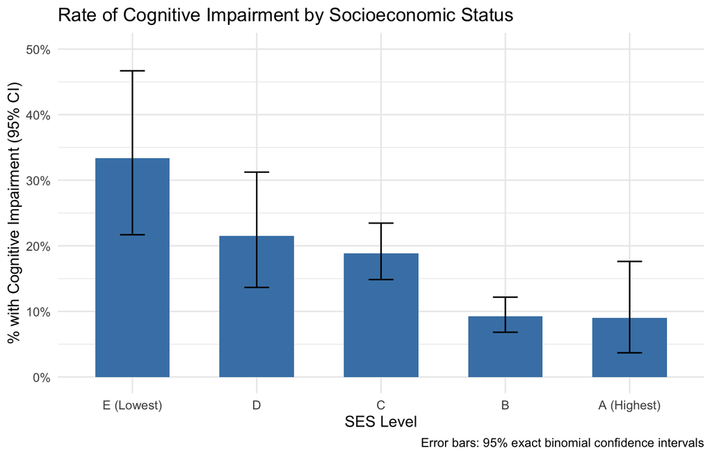

## 3.26 Figure to see how dementia (old and young) varies across sensor populations

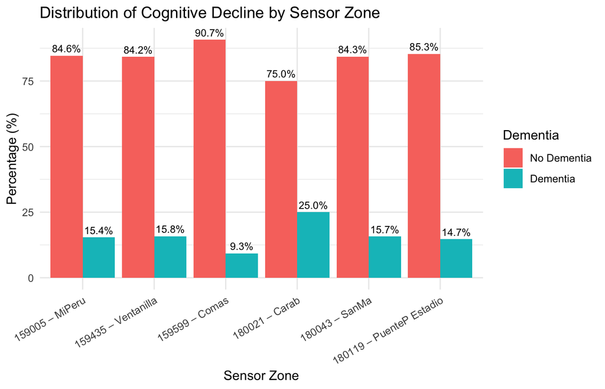

## 3.27 Re: interaction term

```
##
##  ses_level Estimate Std. Error      z Pr(>|z|)   S  2.5 % 97.5 %
##      NSE E    2.125      1.257  1.692   0.0907 3.5 -0.337  4.588
##      NSE D   -1.122      0.833 -1.347   0.1780 2.5 -2.755  0.511
##      NSE C   -1.375      0.566 -2.431   0.0151 6.1 -2.483 -0.266
##      NSE B   -0.323      0.418 -0.773   0.4397 1.2 -1.142  0.496
##      NSE A   -0.125      0.944 -0.133   0.8946 0.2 -1.976  1.726
##
## Term: log_dist_road
## Type: response
## Comparison: dY/dX
```